# RNA-Seq Final Project

### **Control vs AD Group Analysis**

**AD vs Control Correlation Heatmap** We can now generate the same Pearson correlation heatmap from above, though this time seperating by our true varible of interest: AD vs Control.

```r
par(mfrow = c(2, 2))

rlog_corr_coeff <-
  DESeq.rlog %>%
  assay() %>%
  cor(method = "pearson")

selected_genes_rlog_corr_coeff <-
  DESeq.rlog %>%
  subset(rownames(.) %in% most_variable_genes) %>%
  assay() %>%
  cor(method = "pearson")

new_names <-
  rownames(rlog_corr_coeff) %>%
  sapply(function(run_name)
    accession_table[accession_table['Run'] == run_name, 'Diagnosis']) %>%
  {paste0(., '_', str_extract(names(.), '[0-9]{3}$'))}

rlog_corr_coeff <-
  rlog_corr_coeff %>%
  set_rownames(new_names) %>%
  set_colnames(new_names)

new_names <-
  rownames(selected_genes_rlog_corr_coeff) %>%
  sapply(function(run_name)
    accession_table[accession_table['Run'] == run_name, 'Diagnosis']) %>%
  {paste0(., '_', str_extract(names(.), '[0-9]{3}$'))}

selected_genes_rlog_corr_coeff <-
  selected_genes_rlog_corr_coeff %>%
  set_rownames(new_names) %>%
  set_colnames(new_names)
```

Now that we have our `rlog_corr_coeff` and `selected_genes_rlog_corr_coeff` variables, we can plot our results side-by-side below.

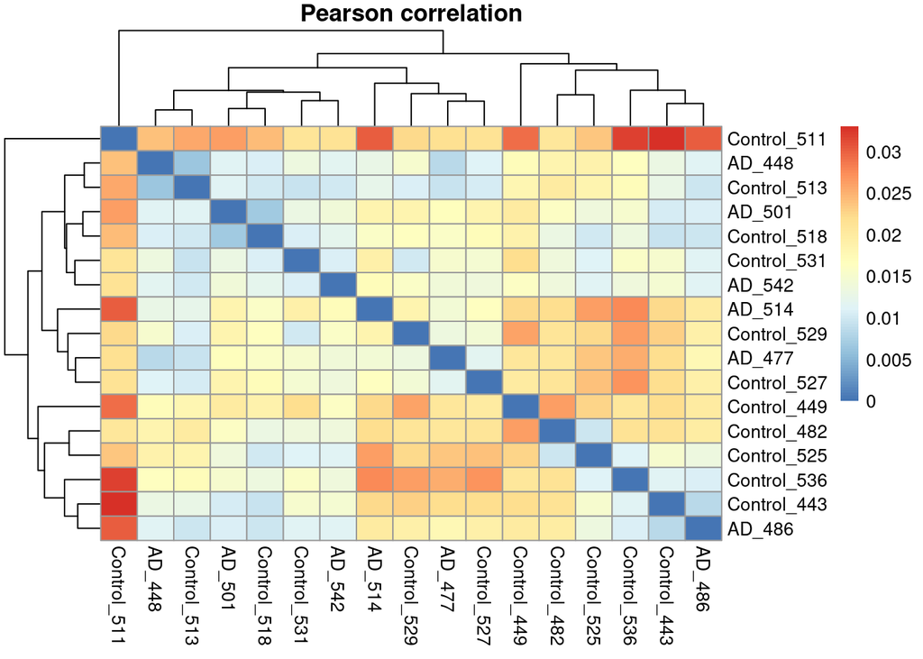

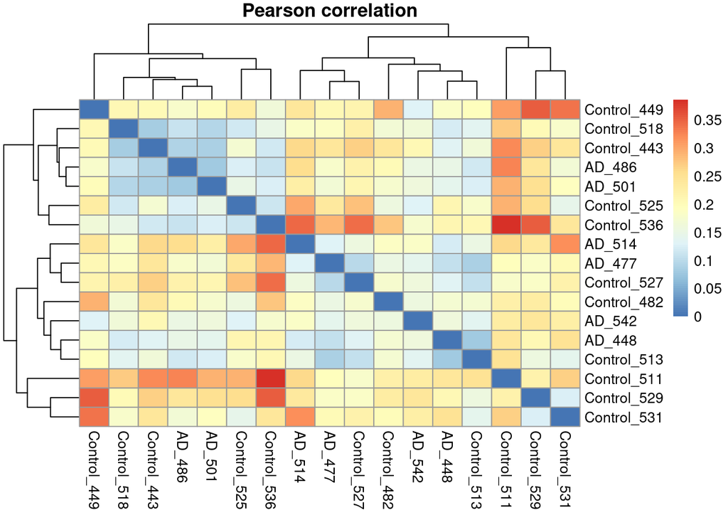

```r
rlog_corr_coeff %>%
  {as.dist(1-., upper = TRUE)} %>%
  as.matrix %>%
  pheatmap::pheatmap(., main = "Pearson correlation")

selected_genes_rlog_corr_coeff %>%
  {as.dist(1-., upper = TRUE)} %>%
  as.matrix %>%
  pheatmap::pheatmap(., main = "Pearson correlation")

DESeq.rlog %>%
  plotPCA(intgroup = 'sex')

DESeq.rlog %>%
  subset(rownames(.) %in% most_variable_genes) %>%
  plotPCA(intgroup = 'sex')
```

[output not shown]

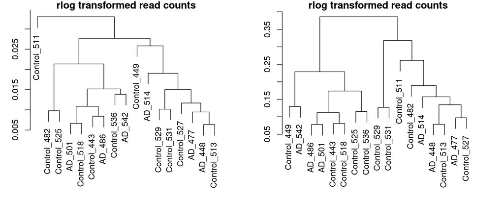

```r
par(mfrow = c(1, 2),
    mar = c(1, 3, 1, 3))

rlog_corr_coeff %>%
  {as.dist(1-.)} %>%
  hclust() %>%
  plot(.,
       main = "rlog transformed read counts",
       xlab = "", ylab = "")

selected_genes_rlog_corr_coeff %>%
  {as.dist(1-.)} %>%
  hclust() %>%
  plot(.,
       main = "rlog transformed read counts",
       xlab = "",  ylab = "")
```

### **Differential Expression Analysis**

[Good DESeq2 differential expression tutorial](https://dputhier.github.io/jgb71e-polytech-bioinfo-app/practical/rna-seq_R/rnaseq_diff_Snf2.html)

```r
# determine DE genes
DESeq.ds <- DESeq(DESeq.ds)

DGE.results <-
  results(DESeq.ds, # extract gene-wise metrics
          independentFiltering = TRUE,
          alpha = 0.05)



# shrink logFC values
DGE.results <-
  lfcShrink(DESeq.ds,
            coef = length(resultsNames(DESeq.ds)),
            res = DGE.results,
            # BiocManager::install('apeglm')
            type = "apeglm")

DGEgenes <-
  DGE.results %>%
  subset(padj < 0.05) %>%
  rownames()

head(DGEgenes)
```

```
[1] "ENSG00000142661.19" "ENSG00000283039.1"  "ENSG00000188641.14"
[4] "ENSG00000196154.12" "ENSG00000010932.17" "ENSG00000152092.16"
```

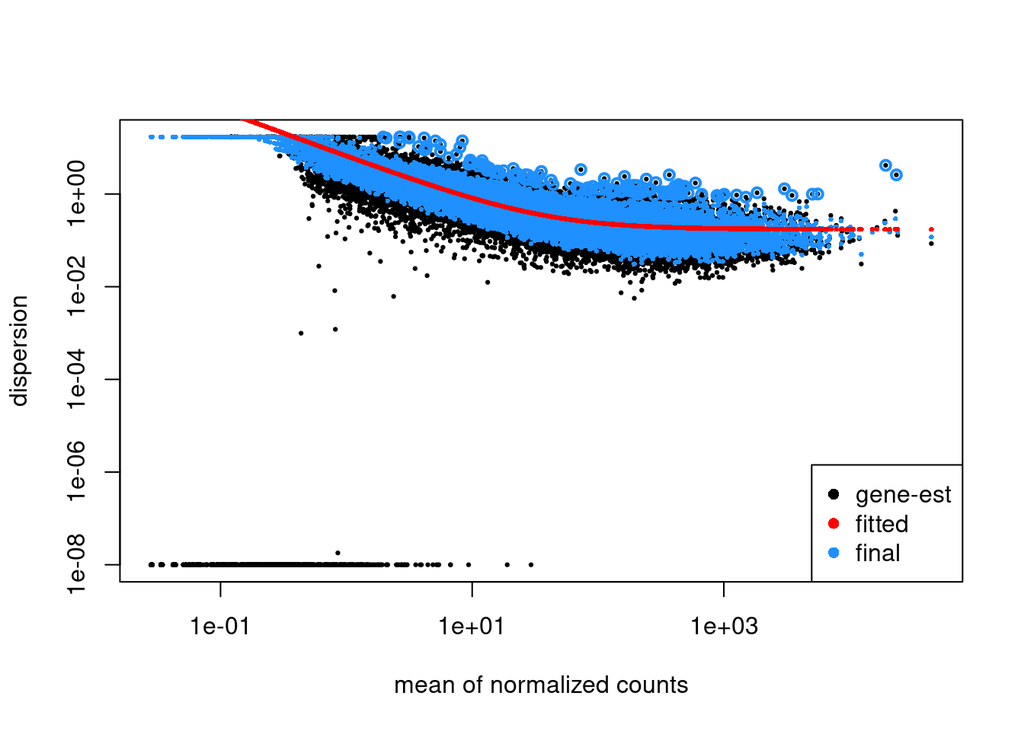

```r
dds.disp <- estimateDispersions(DESeq.ds)
plotDispEsts(dds.disp)
```

[A great resource about how to interpret this plot](https://hbctraining.github.io/DGE_workshop/lessons/04_DGE_DESeq2_analysis.html)

```r
waldTestResult <- nbinomWaldTest(dds.disp)

resultDESeq2 <-
          results(waldTestResult,
                   alpha = 0.05,
                   pAdjustMethod="BH")

ensembl_id_to_gene_symbol <-
  function(ensembl_id) {
    gene_info_df %>%
      .[.$gencode_id == ensembl_id,
        'gene_name']
  }


resultDESeq2 %>%
  .[order(.$padj), ] %>%
  head() %>%
  set_rownames(sapply(rownames(.),
                      ensembl_id_to_gene_symbol)) %>%
  kable()
```

|  | baseMean | log2FoldChange | lfcSE | stat | pvalue | padj |
| --- | --- | --- | --- | --- | --- | --- |
| SERPINF1 | 99.31720 | 1.740736 | 0.2930900 | 5.939254 | 0.0e+00 | 0.0000414 |
| CECR2 | 507.06178 | 1.692270 | 0.2893459 | 5.848605 | 0.0e+00 | 0.0000414 |
| TGFBI | 339.26269 | -1.918785 | 0.3896568 | -4.924296 | 8.0e-07 | 0.0047178 |
| GLT1D1 | 22.99095 | 2.413325 | 0.4982108 | 4.843984 | 1.3e-06 | 0.0053186 |
| MYOM3 | 13.19658 | 4.161175 | 0.8947101 | 4.650864 | 3.3e-06 | 0.0110515 |
| FGL1 | 63.60162 | 2.209185 | 0.4794437 | 4.607809 | 4.1e-06 | 0.0113379 |

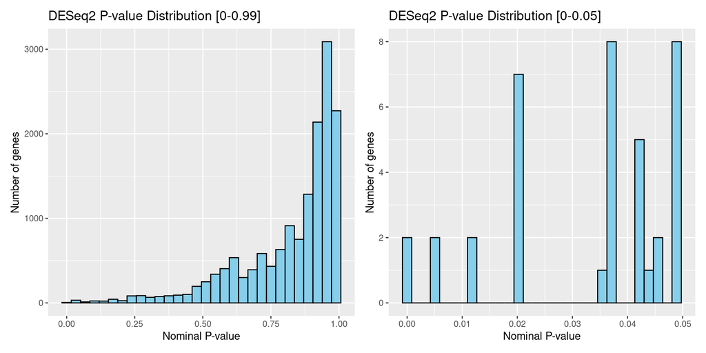

```r
p1 <- resultDESeq2 %>%
  as.data.frame() %>%
  filter(padj <= 0.99) %>%
  ggplot() +
    geom_histogram(aes(x = padj),
                   color = 'black',
                   fill = 'skyblue') +
    xlab('Nominal P-value') +
    ylab('Number of genes') +
    ggtitle('DESeq2 P-value Distribution [0-0.99]')

p2 <- resultDESeq2 %>%
  as.data.frame() %>%
  filter(padj < 0.05) %>%
  ggplot() +
    geom_histogram(aes(x = padj),
                   color = 'black',
                   fill = 'skyblue') +
    xlab('Nominal P-value') +
    ylab('Number of genes') +
    ggtitle('DESeq2 P-value Distribution [0-0.05]')

p1 + p2
```

```r
diff_exp_df <-
  resultDESeq2 %>%
  as.data.frame() %>%
  mutate(gene_name =
           sapply(rownames(.), ensembl_id_to_gene_symbol))

diff_exp_df %>%
  filter(padj < 0.05) %>%
  set_rownames(.$gene_name) %>%
  select(padj, log2FoldChange) %>%
  arrange(padj) %>%
  mutate(padj = format(padj, digits = 2, scientific = FALSE),
         log2FoldChange = format(log2FoldChange, digits = 3)) %>%
  kable()
```

|  | padj | log2FoldChange |
| --- | --- | --- |
| SERPINF1 | 0.000041 | 1.74 |
| CECR2 | 0.000041 | 1.69 |
| TGFBI | 0.004718 | -1.92 |
| GLT1D1 | 0.005319 | 2.41 |
| MYOM3 | 0.011051 | 4.16 |
| FGL1 | 0.011338 | 2.21 |
| S100A4 | 0.019995 | -3.53 |
| FMO1 | 0.019995 | 4.98 |
| PTPRG | 0.019995 | -1.74 |
| PGC | 0.019995 | 4.22 |
| EVPL | 0.019995 | 4.52 |
| APOE | 0.019995 | -1.51 |
| ARSA | 0.019995 | -1.28 |
| KDR | 0.035989 | 3.28 |
| KLF18 | 0.037131 | 5.31 |
| ESRRG | 0.037131 | 2.05 |
| TGM4 | 0.037131 | 2.85 |
| TECTB | 0.037131 | 5.73 |
| KRT77 | 0.037131 | 4.85 |
| EPPIN | 0.037131 | 3.36 |
| MOV10L1 | 0.037131 | 2.54 |
| NEXMIF | 0.037131 | 1.36 |
| ASTN1 | 0.041758 | 1.44 |
| STRIP2 | 0.041758 | 1.77 |
| C2orf16 | 0.042241 | 2.26 |
| DPYD | 0.042672 | -1.86 |
| EDAR | 0.042971 | 2.90 |
| DGKI | 0.044330 | 1.86 |
| STEAP3 | 0.044855 | -1.48 |
| PLEKHG1 | 0.044855 | 1.29 |
| USH2A | 0.048952 | 2.56 |
| CCDC121 | 0.048952 | 1.90 |
| IGSF10 | 0.048952 | 1.57 |
| MCF2L2 | 0.048952 | 1.14 |
| OPRK1 | 0.048952 | 2.66 |
| RGS22 | 0.048952 | 2.79 |
| SORCS1 | 0.048952 | 1.50 |
| PSTPIP1 | 0.048952 | -1.89 |

**Where do the study-selected genes fall in our differential expression table?**

```r
study_selected_genes <- c(
    'LOC102724661', 'ANKRD26P3', 'MOV10L1', 'HIST2H2BA',
    'ZBTB8B', 'GLT1D1', 'TNFRSF21', 'CECR2', 'PDD6IPP2',
    'PTPRZ1', 'IGSF10', 'GRIA2', 'MEIS1', 'SELENBP1',
    'SERPINF1', 'RIMS2', 'ASTN1', 'TLN2', 'ZNF532',
    'ZNF662', 'NIN', 'ULK3', 'SLC38A7', 'FOXP1', 'ARSA',
    'CTBP1-AS', 'LOC102725328', 'CBX6', 'GYPC', 'FBRSL1',
    'SMAD7', 'PLXNC1', 'CLDN15', 'TSHZ3', 'KCNJ5',
    'DPYD', 'STEAP3', 'RUNX3', 'PTPRG', 'ACD', 'TTYH3',
    'LOC100133445', 'LOC102724549', 'VENTX', 'TM9SF1',
    'SMIM3', 'ZNF703', 'TGFBI', 'EMP2', 'PSTPIP1',
    'ZNF696', 'RFX2', 'APOE', 'ATOH8', 'ADAM8', 'GAS2L1',
    'CHCHD5', 'ADAMTS13', 'A1BG', 'IL15', 'SECTM1',
    'FAM109A', 'LOC100507639', 'ZNF843', 'S100A4', 'LSR')


diff_exp_df %>%
  filter(gene_name %in% study_selected_genes) %>%
  # picking top-pvalue ensmbl-gene for each
  # hgnc gene-symbol identified gene
  group_by(gene_name) %>%
  arrange(pvalue) %>%
  filter(row_number() == 1) %>%
  ungroup() %>%
  as.data.frame() %>%
  set_rownames(.$gene_name) %>%
  arrange(padj) %>%
  select(padj, log2FoldChange) %>%
  mutate(padj = format(padj, digits = 2, scientific = FALSE),
         log2FoldChange = format(log2FoldChange, digits = 3)) %>%
  kable()
```

|  | padj | log2FoldChange |
| --- | --- | --- |
| SERPINF1 | 0.000041 | 1.7407 |
| CECR2 | 0.000041 | 1.6923 |
| TGFBI | 0.004718 | -1.9188 |
| GLT1D1 | 0.005319 | 2.4133 |
| ARSA | 0.019995 | -1.2752 |
| PTPRG | 0.019995 | -1.7361 |
| S100A4 | 0.019995 | -3.5340 |
| APOE | 0.019995 | -1.5115 |
| MOV10L1 | 0.037131 | 2.5397 |
| ASTN1 | 0.041758 | 1.4381 |
| DPYD | 0.042672 | -1.8551 |
| STEAP3 | 0.044855 | -1.4818 |
| IGSF10 | 0.048952 | 1.5660 |
| PSTPIP1 | 0.048952 | -1.8852 |
| MEIS1 | 0.059128 | 1.6870 |
| RFX2 | 0.059128 | -1.5431 |
| TNFRSF21 | 0.091389 | 1.9729 |
| SELENBP1 | 0.091389 | 1.5837 |
| PLXNC1 | 0.093845 | -1.2515 |
| SMIM3 | 0.107681 | -1.6002 |
| KCNJ5 | 0.233903 | -1.3691 |
| NIN | 0.240712 | 0.6251 |
| TLN2 | 0.240922 | 0.7447 |
| ACD | 0.240922 | -1.0323 |
| LSR | 0.272270 | -1.0618 |
| VENTX | 0.302060 | -0.9980 |
| SECTM1 | 0.351846 | -2.1158 |
| RIMS2 | 0.361383 | 1.0546 |
| IL15 | 0.365492 | -0.8582 |
| ZNF662 | 0.379506 | 0.7173 |
| PTPRZ1 | 0.382818 | 1.2478 |
| FOXP1 | 0.405825 | -0.6839 |
| ZBTB8B | 0.428732 | 1.6661 |
| GRIA2 | 0.440109 | 1.2523 |
| ZNF532 | 0.446205 | 0.6550 |
| ADAM8 | 0.461316 | -1.3041 |
| TSHZ3 | 0.504754 | -1.0101 |
| TTYH3 | 0.508623 | -0.8394 |
| FBRSL1 | 0.510608 | -0.6324 |
| EMP2 | 0.539124 | -0.9036 |
| SMAD7 | 0.549781 | -0.6461 |
| RUNX3 | 0.553558 | -0.7312 |
| ULK3 | 0.561052 | -0.4504 |
| CBX6 | 0.567129 | -0.4916 |
| SLC38A7 | 0.588293 | -0.4095 |
| CLDN15 | 0.664548 | -0.6452 |
| GYPC | 0.701038 | -0.5979 |
| ADAMTS13 | 0.735986 | -0.7492 |
| GAS2L1 | 0.827672 | -0.4072 |
| ATOH8 | 0.828134 | -0.6446 |
| TM9SF1 | 0.878700 | -0.4394 |
| ZNF703 | 0.886590 | -0.4055 |
| A1BG | 0.896340 | -0.4483 |
| ZNF696 | 0.912330 | -0.3390 |
| ZNF843 | 0.982388 | -0.0933 |
| CHCHD5 | 0.992804 | -0.0474 |

**Which genes have we confirmed from the study-selected genes to be differentially expressed?**

```r
diff_exp_df %>%
  filter(gene_name %in% study_selected_genes,
         padj < 0.05) %>%
  .$gene_name %>% unname()
```

```
 [1] "DPYD"     "S100A4"   "ASTN1"    "STEAP3"   "PTPRG"    "IGSF10"
 [7] "TGFBI"    "GLT1D1"   "PSTPIP1"  "SERPINF1" "APOE"     "CECR2"
[13] "MOV10L1"  "ARSA"
```

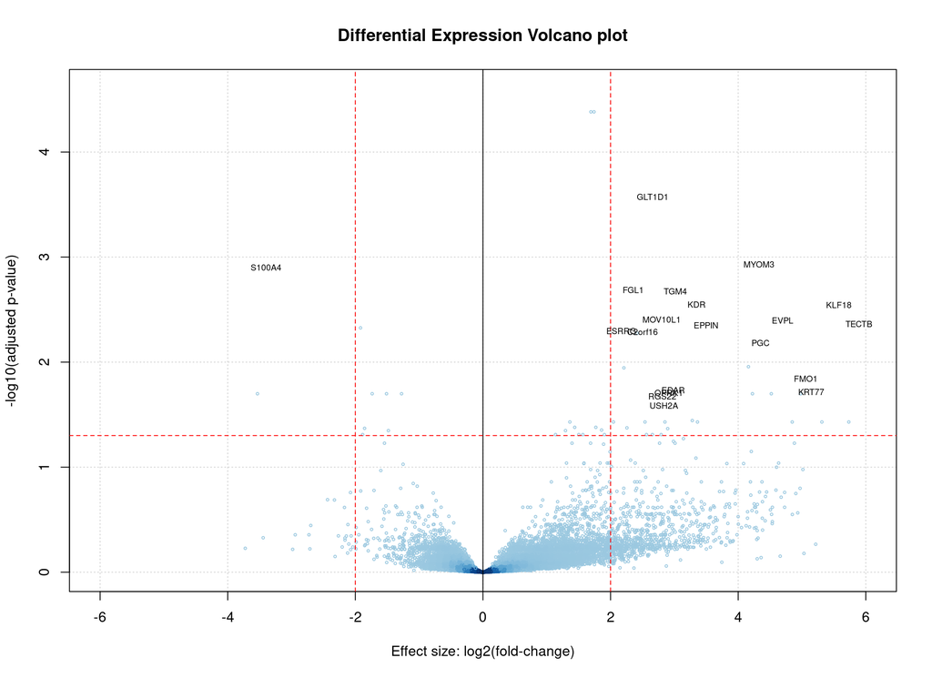

```r
alpha <- 0.05

cols <- densCols(resultDESeq2$log2FoldChange,
                 -log10(resultDESeq2$padj))

plot(resultDESeq2$log2FoldChange,
     -log10(resultDESeq2$padj),
     col=cols, panel.first=grid(),
     main="Differential Expression Volcano plot",
     xlab="Effect size: log2(fold-change)",
     ylab="-log10(adjusted p-value)",
     pch=resultDESeq2$pch, cex=0.4,
     xlim = c(-6,6),
     ylim = c(0, 1.05 *
                max(-log10(resultDESeq2$padj),
                  na.rm = TRUE))
     )

abline(v=0)
abline(v=c(-2,2), lty = 2, col = 'red')
abline(h=-log10(alpha), lty = 2, col = 'red')

# Plot the names of a reasonable number of genes,
# by selecting those begin not only significant but
# also having a strong effect size
genes_to_plot <-
  sapply(abs(resultDESeq2$log2FoldChange) > 2 &
          resultDESeq2$padj < alpha, isTRUE)

labels <-
  genes_to_plot %>%
  {rownames(resultDESeq2)[.]} %>%
  data.frame(query_gencode_id = .) %>%
  left_join(gene_info_df, by = c('query_gencode_id' = 'gencode_id')) %>%
  .$gene_name


if (length(labels) > 0) {
  text(resultDESeq2$log2FoldChange[genes_to_plot] +
                  runif(length(which(genes_to_plot)), 0, 0.3),
       -log10(resultDESeq2$padj[genes_to_plot]) +
                runif(length(which(genes_to_plot)), 0.01, 1.3),
       lab=labels, cex = 0.6)
}
```

**Results**

# **Discussion**

## **Key Datasets Generated**

[output not shown]